# Risk Factor Analysis

## Outcome Variable

**Outcome Variable:** dead0plus

## Predictor Variables

**Intervention Variable:** ever_sunderweight06

**Adjustment Set:**

- sex
- arm
- brthmon
- vagbrth
- impfloor
- hhwealth_quart
- W_mage
- W_mhtcm
- W_mwtkg
- W_mbmi
- W_meducyrs
- W_feducyrs
- W_nrooms
- W_nchldlt5
- W_parity
- impsan
- safeh20
- delta_vagbrth
- delta_impfloor
- delta_hhwealth_quart
- delta_W_mage
- delta_W_mhtcm
- delta_W_mwtkg
- delta_W_mbmi
- delta_W_meducyrs
- delta_W_feducyrs
- delta_W_nrooms
- delta_W_nchldlt5
- delta_W_parity
- delta_impsan
- delta_safeh20

## Stratifying Variables

The analysis was stratified on these variable(s):

- studyid
- country

## Data Summary

| studyid | country | ever_sunderweight06 | dead0plus | n_cell | n | outcome_variable |
| --- | --- | --- | --- | --- | --- | --- |
| ki0047075b-MAL-ED | BANGLADESH | 0 | 0 | 243 | 265 | dead0plus |
| ki0047075b-MAL-ED | BANGLADESH | 0 | 1 | 2 | 265 | dead0plus |
| ki0047075b-MAL-ED | BANGLADESH | 1 | 0 | 19 | 265 | dead0plus |
| ki0047075b-MAL-ED | BANGLADESH | 1 | 1 | 1 | 265 | dead0plus |
| ki0047075b-MAL-ED | INDIA | 0 | 0 | 217 | 251 | dead0plus |
| ki0047075b-MAL-ED | INDIA | 0 | 1 | 1 | 251 | dead0plus |
| ki0047075b-MAL-ED | INDIA | 1 | 0 | 32 | 251 | dead0plus |
| ki0047075b-MAL-ED | INDIA | 1 | 1 | 1 | 251 | dead0plus |
| ki0047075b-MAL-ED | PERU | 0 | 0 | 290 | 303 | dead0plus |
| ki0047075b-MAL-ED | PERU | 0 | 1 | 2 | 303 | dead0plus |
| ki0047075b-MAL-ED | PERU | 1 | 0 | 11 | 303 | dead0plus |
| ki0047075b-MAL-ED | PERU | 1 | 1 | 0 | 303 | dead0plus |
| ki0047075b-MAL-ED | SOUTH AFRICA | 0 | 0 | 300 | 314 | dead0plus |
| ki0047075b-MAL-ED | SOUTH AFRICA | 0 | 1 | 0 | 314 | dead0plus |
| ki0047075b-MAL-ED | SOUTH AFRICA | 1 | 0 | 13 | 314 | dead0plus |
| ki0047075b-MAL-ED | SOUTH AFRICA | 1 | 1 | 1 | 314 | dead0plus |
| ki0047075b-MAL-ED | TANZANIA, UNITED REPUBLIC OF | 0 | 0 | 251 | 262 | dead0plus |
| ki0047075b-MAL-ED | TANZANIA, UNITED REPUBLIC OF | 0 | 1 | 2 | 262 | dead0plus |
| ki0047075b-MAL-ED | TANZANIA, UNITED REPUBLIC OF | 1 | 0 | 8 | 262 | dead0plus |
| ki0047075b-MAL-ED | TANZANIA, UNITED REPUBLIC OF | 1 | 1 | 1 | 262 | dead0plus |
| ki1000109-EE | PAKISTAN | 0 | 0 | 218 | 380 | dead0plus |
| ki1000109-EE | PAKISTAN | 0 | 1 | 1 | 380 | dead0plus |
| ki1000109-EE | PAKISTAN | 1 | 0 | 158 | 380 | dead0plus |
| ki1000109-EE | PAKISTAN | 1 | 1 | 3 | 380 | dead0plus |
| ki1000304-VITAMIN-A | INDIA | 0 | 0 | 2858 | 3906 | dead0plus |
| ki1000304-VITAMIN-A | INDIA | 0 | 1 | 30 | 3906 | dead0plus |
| ki1000304-VITAMIN-A | INDIA | 1 | 0 | 970 | 3906 | dead0plus |
| ki1000304-VITAMIN-A | INDIA | 1 | 1 | 48 | 3906 | dead0plus |
| ki1000304b-SAS-CompFeed | INDIA | 0 | 0 | 1247 | 1533 | dead0plus |
| ki1000304b-SAS-CompFeed | INDIA | 0 | 1 | 26 | 1533 | dead0plus |
| ki1000304b-SAS-CompFeed | INDIA | 1 | 0 | 236 | 1533 | dead0plus |
| ki1000304b-SAS-CompFeed | INDIA | 1 | 1 | 24 | 1533 | dead0plus |
| ki1000304b-SAS-FoodSuppl | INDIA | 0 | 0 | 304 | 416 | dead0plus |
| ki1000304b-SAS-FoodSuppl | INDIA | 0 | 1 | 2 | 416 | dead0plus |
| ki1000304b-SAS-FoodSuppl | INDIA | 1 | 0 | 106 | 416 | dead0plus |
| ki1000304b-SAS-FoodSuppl | INDIA | 1 | 1 | 4 | 416 | dead0plus |
| ki1017093b-PROVIDE | BANGLADESH | 0 | 0 | 647 | 700 | dead0plus |
| ki1017093b-PROVIDE | BANGLADESH | 0 | 1 | 5 | 700 | dead0plus |
| ki1017093b-PROVIDE | BANGLADESH | 1 | 0 | 48 | 700 | dead0plus |
| ki1017093b-PROVIDE | BANGLADESH | 1 | 1 | 0 | 700 | dead0plus |
| ki1066203-TanzaniaChild2 | TANZANIA, UNITED REPUBLIC OF | 0 | 0 | 2325 | 2396 | dead0plus |
| ki1066203-TanzaniaChild2 | TANZANIA, UNITED REPUBLIC OF | 0 | 1 | 1 | 2396 | dead0plus |
| ki1066203-TanzaniaChild2 | TANZANIA, UNITED REPUBLIC OF | 1 | 0 | 70 | 2396 | dead0plus |
| ki1066203-TanzaniaChild2 | TANZANIA, UNITED REPUBLIC OF | 1 | 1 | 0 | 2396 | dead0plus |
| ki1101329-Keneba | GAMBIA | 0 | 0 | 2379 | 2632 | dead0plus |
| ki1101329-Keneba | GAMBIA | 0 | 1 | 71 | 2632 | dead0plus |
| ki1101329-Keneba | GAMBIA | 1 | 0 | 158 | 2632 | dead0plus |
| ki1101329-Keneba | GAMBIA | 1 | 1 | 24 | 2632 | dead0plus |
| ki1112895-Burkina Faso Zn | BURKINA FASO | 0 | 0 | 315 | 338 | dead0plus |
| ki1112895-Burkina Faso Zn | BURKINA FASO | 0 | 1 | 2 | 338 | dead0plus |
| ki1112895-Burkina Faso Zn | BURKINA FASO | 1 | 0 | 21 | 338 | dead0plus |
| ki1112895-Burkina Faso Zn | BURKINA FASO | 1 | 1 | 0 | 338 | dead0plus |
| ki1113344-GMS-Nepal | NEPAL | 0 | 0 | 600 | 697 | dead0plus |
| ki1113344-GMS-Nepal | NEPAL | 0 | 1 | 3 | 697 | dead0plus |
| ki1113344-GMS-Nepal | NEPAL | 1 | 0 | 90 | 697 | dead0plus |
| ki1113344-GMS-Nepal | NEPAL | 1 | 1 | 4 | 697 | dead0plus |
| ki1126311-ZVITAMBO | ZIMBABWE | 0 | 0 | 12411 | 14085 | dead0plus |
| ki1126311-ZVITAMBO | ZIMBABWE | 0 | 1 | 816 | 14085 | dead0plus |
| ki1126311-ZVITAMBO | ZIMBABWE | 1 | 0 | 556 | 14085 | dead0plus |
| ki1126311-ZVITAMBO | ZIMBABWE | 1 | 1 | 302 | 14085 | dead0plus |
| ki1148112-iLiNS-DOSE | MALAWI | 0 | 0 | 1646 | 1816 | dead0plus |
| ki1148112-iLiNS-DOSE | MALAWI | 0 | 1 | 106 | 1816 | dead0plus |
| ki1148112-iLiNS-DOSE | MALAWI | 1 | 0 | 56 | 1816 | dead0plus |
| ki1148112-iLiNS-DOSE | MALAWI | 1 | 1 | 8 | 1816 | dead0plus |
| ki1148112-iLiNS-DYAD-M | MALAWI | 0 | 0 | 1082 | 1202 | dead0plus |
| ki1148112-iLiNS-DYAD-M | MALAWI | 0 | 1 | 31 | 1202 | dead0plus |
| ki1148112-iLiNS-DYAD-M | MALAWI | 1 | 0 | 76 | 1202 | dead0plus |
| ki1148112-iLiNS-DYAD-M | MALAWI | 1 | 1 | 13 | 1202 | dead0plus |
| kiGH5241-JiVitA-3 | BANGLADESH | 0 | 0 | 22216 | 27237 | dead0plus |
| kiGH5241-JiVitA-3 | BANGLADESH | 0 | 1 | 436 | 27237 | dead0plus |
| kiGH5241-JiVitA-3 | BANGLADESH | 1 | 0 | 4155 | 27237 | dead0plus |
| kiGH5241-JiVitA-3 | BANGLADESH | 1 | 1 | 430 | 27237 | dead0plus |
| kiGH5241-JiVitA-4 | BANGLADESH | 0 | 0 | 4716 | 5276 | dead0plus |
| kiGH5241-JiVitA-4 | BANGLADESH | 0 | 1 | 32 | 5276 | dead0plus |
| kiGH5241-JiVitA-4 | BANGLADESH | 1 | 0 | 512 | 5276 | dead0plus |
| kiGH5241-JiVitA-4 | BANGLADESH | 1 | 1 | 16 | 5276 | dead0plus |

The following strata were considered:

- studyid: ki0047075b-MAL-ED, country: BANGLADESH
- studyid: ki0047075b-MAL-ED, country: INDIA
- studyid: ki0047075b-MAL-ED, country: PERU
- studyid: ki0047075b-MAL-ED, country: SOUTH AFRICA
- studyid: ki0047075b-MAL-ED, country: TANZANIA, UNITED REPUBLIC OF
- studyid: ki1000109-EE, country: PAKISTAN
- studyid: ki1000304-VITAMIN-A, country: INDIA
- studyid: ki1000304b-SAS-CompFeed, country: INDIA
- studyid: ki1000304b-SAS-FoodSuppl, country: INDIA
- studyid: ki1017093b-PROVIDE, country: BANGLADESH
- studyid: ki1066203-TanzaniaChild2, country: TANZANIA, UNITED REPUBLIC OF
- studyid: ki1101329-Keneba, country: GAMBIA
- studyid: ki1112895-Burkina Faso Zn, country: BURKINA FASO
- studyid: ki1113344-GMS-Nepal, country: NEPAL
- studyid: ki1126311-ZVITAMBO, country: ZIMBABWE
- studyid: ki1148112-iLiNS-DOSE, country: MALAWI
- studyid: ki1148112-iLiNS-DYAD-M, country: MALAWI
- studyid: kiGH5241-JiVitA-3, country: BANGLADESH
- studyid: kiGH5241-JiVitA-4, country: BANGLADESH

### Dropped Strata

Some strata were dropped due to rare outcomes:

- studyid: ki0047075b-MAL-ED, country: BANGLADESH
- studyid: ki0047075b-MAL-ED, country: INDIA
- studyid: ki0047075b-MAL-ED, country: PERU
- studyid: ki0047075b-MAL-ED, country: SOUTH AFRICA
- studyid: ki0047075b-MAL-ED, country: TANZANIA, UNITED REPUBLIC OF
- studyid: ki1000109-EE, country: PAKISTAN
- studyid: ki1000304b-SAS-FoodSuppl, country: INDIA
- studyid: ki1017093b-PROVIDE, country: BANGLADESH
- studyid: ki1066203-TanzaniaChild2, country: TANZANIA, UNITED REPUBLIC OF
- studyid: ki1112895-Burkina Faso Zn, country: BURKINA FASO
- studyid: ki1113344-GMS-Nepal, country: NEPAL

## Methods Detail

We’re interested in the causal parameters $E[Y_a]$ for all values of $a \in \mathcal{A}$. These parameters represent the mean outcome if, possibly contrary to fact, we intervened to set all units to have $A=a$. Under the randomization and positivity assumptions, these are identified by the statistical parameters $\psi_a=E_W[E_{Y|A,W}(Y|A=a,W)]$. In addition, we’re interested in the mean of $Y$, $E[Y]$ under no intervention (the observed mean). We will estimate these parameters by using SuperLearner to fit the relevant likelihood factors – $E_{Y|A,W}(Y|A=a,W)$ and $p(A=a|W)$, and then updating our likelihood fit using a joint TMLE.

For unadjusted analyses ($W=\{\}$), initial likelihoods were estimated using Lrnr_glm to estimate the simple $E(Y|A)$ and Lrnr_mean to estimate $p(A)$. For adjusted analyses, a small library containing Lrnr_glmnet, Lrnr_xgboost, and Lrnr_mean was used.

Having estimated these parameters, we will then use the delta method to estimate relative risks and attributable risks relative to a prespecified baseline level of $A$.

# Results Detail

## Results Plots

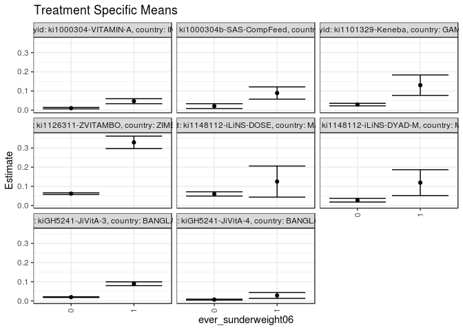

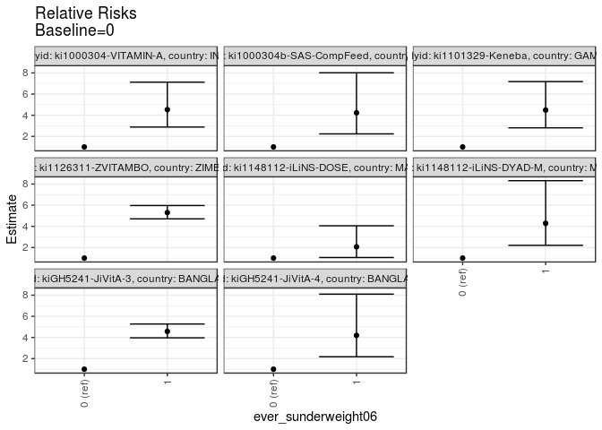

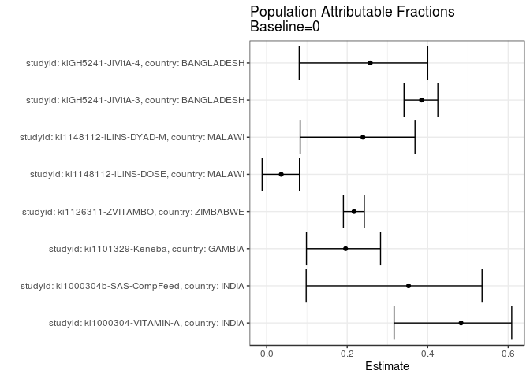

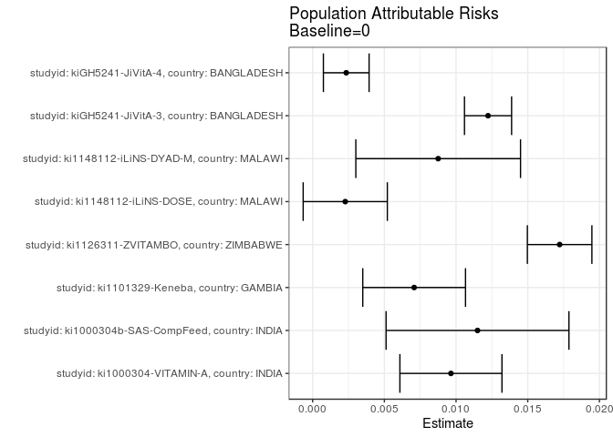

## Results Table

### Parameter: TSM

| studyid | country | intervention_level | baseline_level | estimate | ci_lower | ci_upper |
| --- | --- | --- | --- | --- | --- | --- |
| ki1000304-VITAMIN-A | INDIA | 0 | NA | 0.0103260 | 0.0066403 | 0.0140118 |
| ki1000304-VITAMIN-A | INDIA | 1 | NA | 0.0467916 | 0.0337525 | 0.0598307 |
| ki1000304b-SAS-CompFeed | INDIA | 0 | NA | 0.0211192 | 0.0084969 | 0.0337415 |
| ki1000304b-SAS-CompFeed | INDIA | 1 | NA | 0.0893510 | 0.0574175 | 0.1212846 |
| ki1101329-Keneba | GAMBIA | 0 | NA | 0.0290172 | 0.0223649 | 0.0356694 |
| ki1101329-Keneba | GAMBIA | 1 | NA | 0.1302568 | 0.0769312 | 0.1835823 |
| ki1126311-ZVITAMBO | ZIMBABWE | 0 | NA | 0.0621509 | 0.0580381 | 0.0662638 |
| ki1126311-ZVITAMBO | ZIMBABWE | 1 | NA | 0.3295179 | 0.2970044 | 0.3620314 |
| ki1148112-iLiNS-DOSE | MALAWI | 0 | NA | 0.0605023 | 0.0493353 | 0.0716692 |
| ki1148112-iLiNS-DOSE | MALAWI | 1 | NA | 0.1250000 | 0.0439530 | 0.2060470 |
| ki1148112-iLiNS-DYAD-M | MALAWI | 0 | NA | 0.0278522 | 0.0181767 | 0.0375277 |
| ki1148112-iLiNS-DYAD-M | MALAWI | 1 | NA | 0.1192748 | 0.0516713 | 0.1868783 |
| kiGH5241-JiVitA-3 | BANGLADESH | 0 | NA | 0.0195639 | 0.0177474 | 0.0213804 |
| kiGH5241-JiVitA-3 | BANGLADESH | 1 | NA | 0.0894691 | 0.0794566 | 0.0994816 |
| kiGH5241-JiVitA-4 | BANGLADESH | 0 | NA | 0.0067558 | 0.0042422 | 0.0092694 |
| kiGH5241-JiVitA-4 | BANGLADESH | 1 | NA | 0.0283583 | 0.0131070 | 0.0436095 |

### Parameter: E(Y)

| studyid | country | intervention_level | baseline_level | estimate | ci_lower | ci_upper |
| --- | --- | --- | --- | --- | --- | --- |
| ki1000304-VITAMIN-A | INDIA | NA | NA | 0.0199693 | 0.0155816 | 0.0243570 |
| ki1000304b-SAS-CompFeed | INDIA | NA | NA | 0.0326158 | 0.0204960 | 0.0447355 |
| ki1101329-Keneba | GAMBIA | NA | NA | 0.0360942 | 0.0289669 | 0.0432215 |
| ki1126311-ZVITAMBO | ZIMBABWE | NA | NA | 0.0793752 | 0.0749108 | 0.0838397 |
| ki1148112-iLiNS-DOSE | MALAWI | NA | NA | 0.0627753 | 0.0516163 | 0.0739344 |
| ki1148112-iLiNS-DYAD-M | MALAWI | NA | NA | 0.0366057 | 0.0259850 | 0.0472263 |
| kiGH5241-JiVitA-3 | BANGLADESH | NA | NA | 0.0317950 | 0.0295928 | 0.0339972 |
| kiGH5241-JiVitA-4 | BANGLADESH | NA | NA | 0.0090978 | 0.0063582 | 0.0118374 |

### Parameter: RR

| studyid | country | intervention_level | baseline_level | estimate | ci_lower | ci_upper |
| --- | --- | --- | --- | --- | --- | --- |
| ki1000304-VITAMIN-A | INDIA | 0 | 0 | 1.000000 | 1.000000 | 1.000000 |
| ki1000304-VITAMIN-A | INDIA | 1 | 0 | 4.531417 | 2.880941 | 7.127442 |
| ki1000304b-SAS-CompFeed | INDIA | 0 | 0 | 1.000000 | 1.000000 | 1.000000 |
| ki1000304b-SAS-CompFeed | INDIA | 1 | 0 | 4.230803 | 2.234010 | 8.012361 |
| ki1101329-Keneba | GAMBIA | 0 | 0 | 1.000000 | 1.000000 | 1.000000 |
| ki1101329-Keneba | GAMBIA | 1 | 0 | 4.488956 | 2.806523 | 7.179961 |
| ki1126311-ZVITAMBO | ZIMBABWE | 0 | 0 | 1.000000 | 1.000000 | 1.000000 |
| ki1126311-ZVITAMBO | ZIMBABWE | 1 | 0 | 5.301898 | 4.709215 | 5.969175 |
| ki1148112-iLiNS-DOSE | MALAWI | 0 | 0 | 1.000000 | 1.000000 | 1.000000 |
| ki1148112-iLiNS-DOSE | MALAWI | 1 | 0 | 2.066038 | 1.052847 | 4.054256 |
| ki1148112-iLiNS-DYAD-M | MALAWI | 0 | 0 | 1.000000 | 1.000000 | 1.000000 |
| ki1148112-iLiNS-DYAD-M | MALAWI | 1 | 0 | 4.282420 | 2.204838 | 8.317672 |
| kiGH5241-JiVitA-3 | BANGLADESH | 0 | 0 | 1.000000 | 1.000000 | 1.000000 |
| kiGH5241-JiVitA-3 | BANGLADESH | 1 | 0 | 4.573177 | 3.967918 | 5.270762 |
| kiGH5241-JiVitA-4 | BANGLADESH | 0 | 0 | 1.000000 | 1.000000 | 1.000000 |
| kiGH5241-JiVitA-4 | BANGLADESH | 1 | 0 | 4.197621 | 2.175955 | 8.097603 |

### Parameter: PAR

| studyid | country | intervention_level | baseline_level | estimate | ci_lower | ci_upper |
| --- | --- | --- | --- | --- | --- | --- |
| ki1000304-VITAMIN-A | INDIA | 0 | NA | 0.0096432 | 0.0060840 | 0.0132024 |
| ki1000304b-SAS-CompFeed | INDIA | 0 | NA | 0.0114966 | 0.0051202 | 0.0178731 |
| ki1101329-Keneba | GAMBIA | 0 | NA | 0.0070771 | 0.0034945 | 0.0106596 |
| ki1126311-ZVITAMBO | ZIMBABWE | 0 | NA | 0.0172243 | 0.0149744 | 0.0194742 |
| ki1148112-iLiNS-DOSE | MALAWI | 0 | NA | 0.0022730 | -0.0006617 | 0.0052078 |
| ki1148112-iLiNS-DYAD-M | MALAWI | 0 | NA | 0.0087535 | 0.0030105 | 0.0144964 |
| kiGH5241-JiVitA-3 | BANGLADESH | 0 | NA | 0.0122311 | 0.0105883 | 0.0138739 |
| kiGH5241-JiVitA-4 | BANGLADESH | 0 | NA | 0.0023420 | 0.0007487 | 0.0039353 |

### Parameter: PAF

| studyid | country | intervention_level | baseline_level | estimate | ci_lower | ci_upper |
| --- | --- | --- | --- | --- | --- | --- |
| ki1000304-VITAMIN-A | INDIA | 0 | NA | 0.4829032 | 0.3164613 | 0.6088165 |
| ki1000304b-SAS-CompFeed | INDIA | 0 | NA | 0.3524864 | 0.0981394 | 0.5351013 |
| ki1101329-Keneba | GAMBIA | 0 | NA | 0.1960719 | 0.0987846 | 0.2828569 |
| ki1126311-ZVITAMBO | ZIMBABWE | 0 | NA | 0.2169983 | 0.1905979 | 0.2425376 |
| ki1148112-iLiNS-DOSE | MALAWI | 0 | NA | 0.0362092 | -0.0112860 | 0.0814739 |
| ki1148112-iLiNS-DYAD-M | MALAWI | 0 | NA | 0.2391285 | 0.0832100 | 0.3685300 |
| kiGH5241-JiVitA-3 | BANGLADESH | 0 | NA | 0.3846866 | 0.3412347 | 0.4252724 |
| kiGH5241-JiVitA-4 | BANGLADESH | 0 | NA | 0.2574257 | 0.0808666 | 0.4000691 |